# clf_model

### Libraries

```python
import pandas as pd
import numpy as np

import matplotlib.pyplot as plt
import seaborn as sns

import sweetviz

from sklearn.model_selection import train_test_split

from pycaret.classification import *
```

```python
## python version
import sys
print(sys.version)
```

```
3.9.9 (main, Nov 21 2021, 03:23:42)
[Clang 13.0.0 (clang-1300.0.29.3)]
```

### Objective

it is more cost-efficient for customers to make payments through our self-service channels such as online or through the automated phone system. We would like to use **a predictive model to select people to receive a pre-emptive e-mail message designed to encourage them to pay online.**

You have been tasked with identifying which customers are likely to make a service payment call in the next 5 days. The attached file contains data on customers who have had a bill due in the next 5 days and whether they made a service payment call. Construct a model that predicts the likelihood that each policyholder will make a service payment call `(CALL_FLAG=1)`.

### Load and clean

```python
def load_data():
    df = pd.read_csv("..//data/DS_MiniProject_ANON.csv")
    return df

def clean_data(df):
    ## drop the nulls -- justification above in the data
    df = df.dropna()

    ## the data in the six months should be int -- payment numbers are discrete
    six_months   = df.filter(regex = r"_6M", axis = 1)
    df[list(six_months)] = df[list(six_months)].astype(np.int)

    ##same for recent payment its a binary
    df["RECENT_PAYMENT"] = df["RECENT_PAYMENT"].astype(np.int)

    ## delete
    del df["DATE_FOR"]

    return df

## build and clean
df = load_data()
df = (df.pipe(clean_data))
```

### Explore Data

#### Target Variable Distribution

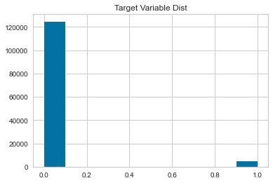

```python
%matplotlib inline
df["Call_Flag"].hist()
plt.title("Target Variable Dist")
plt.show()
```

#### Profiling -- SweetViz

I really like Sweetviz as its pretty and honestly really easy to share out I'm gonna leave it here, but not going to include all of the distributions for the sake of brevity we list the categorical features as well as the numeric and build the intuition for the model pipeline

```python
sweet = sweetviz.analyze("train", df,target_feat='Call_Flag')
sweet.show_html('..//reporting//EDA.html')
```

```
                                             |      | [  0%]   00:00 -> (? left)
```

```
Report ..//reporting//EDA.html was generated! NOTEBOOK/COLAB USERS: the web browser MAY not pop up, regardless, the report IS saved in your notebook/colab files.
```

Lotta long tailed distributions consider some sort of binning or normalization to ensure not learning a specific point for the sparse points

Love the Association Chart, will probably need some sort of boosting or bagging with all these weak learners and sparse data, can already tell its a gbm type model

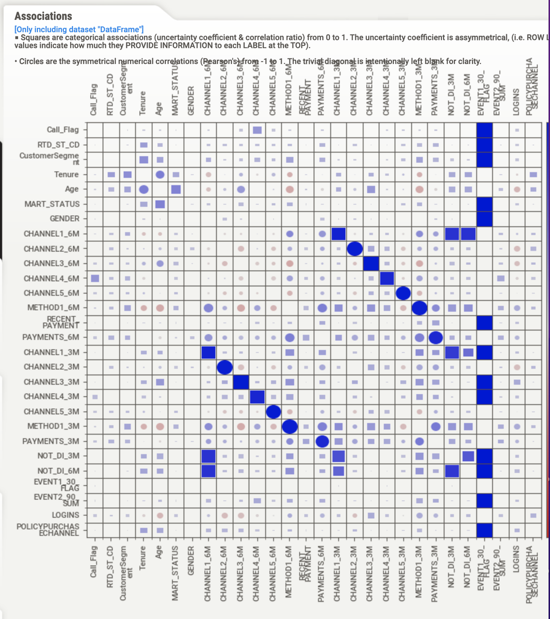

### Modeling

#### Model Definition

```python
## feature select
categorical_   = ['RTD_ST_CD',
                 'CustomerSegment',
                  'MART_STATUS',
                  'GENDER',
                  'RECENT_PAYMENT',
                  'NOT_DI_3M',
                 'NOT_DI_6M',
                 'EVENT1_30_FLAG',
                  'POLICYPURCHASECHANNEL']


numeric_       = ['Tenure',
                     'CHANNEL1_6M',
                     'CHANNEL2_6M',
                     'CHANNEL3_6M',
                     'CHANNEL4_6M',
                     'CHANNEL5_6M',
                     'METHOD1_6M',
                     'PAYMENTS_6M',
                     'CHANNEL1_3M',
                     'CHANNEL2_3M',
                     'CHANNEL3_3M',
                     'CHANNEL4_3M',
                     'CHANNEL5_3M',
                     'METHOD1_3M',
                     'PAYMENTS_3M',
                      'EVENT2_90_SUM',
                     'LOGINS',
                      "Age"
                     ]
```

#### Split Data

The models will be built using `KfoldStratified Cross validation` and oversampling the training set using `SMOTE`. The main reason for this is we want to be able to tune the recall and precision, which SMOTE is good for

We will also build a holdout set for final predictions

```python
train, holdout = train_test_split(df,
                                  test_size = 0.05,
                                  shuffle = True,
                                  random_state = 1337)
```

```python
## double checking distribution train
print(train["Call_Flag"].value_counts() / len(train) * 100)
```

```
0    96.335893
1     3.664107
Name: Call_Flag, dtype: float64
```

```python
## double checking distribution test
print(holdout["Call_Flag"].value_counts() / len(holdout) * 100)
```

```
0    96.519183
1     3.480817
Name: Call_Flag, dtype: float64
```

```python
## fix imbalance -- using SMOTE
exp_clf = setup(data          = train,
                target        = "Call_Flag",
                fix_imbalance = True,
                normalize     = True,
                transformation = True,
                ignore_low_variance = True,
                use_gpu = True,
                remove_multicollinearity = True,
                multicollinearity_threshold = 0.95,
                numeric_features = numeric_,
                categorical_features = categorical_,
                fold_strategy = "stratifiedkfold",
                data_split_stratify = True,
                session_id = 1337
                )
```

|  | Description | Value |
| --- | --- | --- |
| 0 | session_id | 1337 |
| 1 | Target | Call_Flag |
| 2 | Target Type | Binary |
| 3 | Label Encoded | None |
| 4 | Original Data | (122813, 28) |
| 5 | Missing Values | False |
| 6 | Numeric Features | 18 |
| 7 | Categorical Features | 9 |
| 8 | Ordinal Features | False |
| 9 | High Cardinality Features | False |
| 10 | High Cardinality Method | None |
| 11 | Transformed Train Set | (85969, 81) |
| 12 | Transformed Test Set | (36844, 81) |
| 13 | Shuffle Train-Test | True |
| 14 | Stratify Train-Test | True |
| 15 | Fold Generator | StratifiedKFold |
| 16 | Fold Number | 10 |
| 17 | CPU Jobs | -1 |
| 18 | Use GPU | True |
| 19 | Log Experiment | False |
| 20 | Experiment Name | clf-default-name |
| 21 | USI | d1d6 |
| 22 | Imputation Type | simple |
| 23 | Iterative Imputation Iteration | None |
| 24 | Numeric Imputer | mean |
| 25 | Iterative Imputation Numeric Model | None |
| 26 | Categorical Imputer | constant |
| 27 | Iterative Imputation Categorical Model | None |
| 28 | Unknown Categoricals Handling | least_frequent |
| 29 | Normalize | True |
| 30 | Normalize Method | zscore |
| 31 | Transformation | True |
| 32 | Transformation Method | yeo-johnson |
| 33 | PCA | False |
| 34 | PCA Method | None |
| 35 | PCA Components | None |
| 36 | Ignore Low Variance | True |
| 37 | Combine Rare Levels | False |
| 38 | Rare Level Threshold | None |
| 39 | Numeric Binning | False |
| 40 | Remove Outliers | False |
| 41 | Outliers Threshold | None |
| 42 | Remove Multicollinearity | True |
| 43 | Multicollinearity Threshold | 0.950000 |
| 44 | Remove Perfect Collinearity | True |
| 45 | Clustering | False |
| 46 | Clustering Iteration | None |
| 47 | Polynomial Features | False |
| 48 | Polynomial Degree | None |
| 49 | Trignometry Features | False |
| 50 | Polynomial Threshold | None |
| 51 | Group Features | False |
| 52 | Feature Selection | False |
| 53 | Feature Selection Method | classic |
| 54 | Features Selection Threshold | None |
| 55 | Feature Interaction | False |
| 56 | Feature Ratio | False |
| 57 | Interaction Threshold | None |
| 58 | Fix Imbalance | True |
| 59 | Fix Imbalance Method | SMOTE |

### Compare Models

The great advantage of pycaret is we can easily look at a whole bunch of common sklearn classifiers and get an idea of if any stand out as good candidate models

In this way we are more concerned with "recall" or the tp / (tp + fn) ratio. Espicially in an unbalanced dataset, what we care about here is the amount of tn and tp, this is intuition and we would have to establish that with a subject matter expert but we care way more aboutg a false negative than a false positive

```python
compare_models()
```

|  | Model | Accuracy | AUC | Recall | Prec. | F1 | Kappa | MCC | TT (Sec) |
| --- | --- | --- | --- | --- | --- | --- | --- | --- | --- |
| dummy | Dummy Classifier | 0.9635 | 0.5000 | 0.0000 | 0.0000 | 0.0000 | 0.0000 | 0.0000 | 0.9720 |
| rf | Random Forest Classifier | 0.9581 | 0.8292 | 0.1554 | 0.3398 | 0.2131 | 0.1947 | 0.2106 | 11.5470 |
| et | Extra Trees Classifier | 0.9553 | 0.8120 | 0.1693 | 0.3014 | 0.2167 | 0.1956 | 0.2043 | 22.8620 |
| lightgbm | Light Gradient Boosting Machine | 0.9544 | 0.8520 | 0.2658 | 0.3427 | 0.2989 | 0.2757 | 0.2784 | 2.4930 |
| dt | Decision Tree Classifier | 0.9334 | 0.5854 | 0.2099 | 0.1694 | 0.1874 | 0.1531 | 0.1541 | 3.7550 |
| gbc | Gradient Boosting Classifier | 0.9098 | 0.8489 | 0.5113 | 0.2058 | 0.2933 | 0.2545 | 0.2849 | 46.3850 |
| ada | Ada Boost Classifier | 0.8715 | 0.8360 | 0.5954 | 0.1609 | 0.2532 | 0.2076 | 0.2619 | 11.1600 |
| knn | K Neighbors Classifier | 0.8245 | 0.7412 | 0.5570 | 0.1133 | 0.1883 | 0.1358 | 0.1914 | 30.4270 |
| ridge | Ridge Classifier | 0.7767 | 0.0000 | 0.7669 | 0.1154 | 0.2006 | 0.1464 | 0.2380 | 1.3160 |
| lda | Linear Discriminant Analysis | 0.7767 | 0.8426 | 0.7669 | 0.1154 | 0.2006 | 0.1464 | 0.2380 | 3.9880 |
| lr | Logistic Regression | 0.7763 | 0.8405 | 0.7599 | 0.1145 | 0.1989 | 0.1446 | 0.2350 | 10.6350 |
| svm | SVM - Linear Kernel | 0.7550 | 0.0000 | 0.7793 | 0.1076 | 0.1890 | 0.1334 | 0.2270 | 2.3490 |
| nb | Naive Bayes | 0.4417 | 0.7060 | 0.7747 | 0.0490 | 0.0921 | 0.0251 | 0.0774 | 1.1980 |
| qda | Quadratic Discriminant Analysis | 0.0365 | 0.5000 | 1.0000 | 0.0365 | 0.0705 | 0.0000 | 0.0000 | 2.2340 |

```
DummyClassifier(constant=None, random_state=1337, strategy='prior')
```

### Candidate Model - Light GBM

#### create model

```python
light_gbm = create_model('lightgbm')
```

| Fold | Accuracy | AUC | Recall | Prec. | F1 | Kappa | MCC |
| --- | --- | --- | --- | --- | --- | --- | --- |
| 0 | 0.9600 | 0.8671 | 0.2317 | 0.4171 | 0.2980 | 0.2791 | 0.2919 |
| 1 | 0.9581 | 0.8767 | 0.2508 | 0.3892 | 0.3050 | 0.2845 | 0.2918 |
| 2 | 0.9598 | 0.8496 | 0.2381 | 0.4144 | 0.3024 | 0.2833 | 0.2948 |
| 3 | 0.9554 | 0.8612 | 0.2571 | 0.3522 | 0.2972 | 0.2748 | 0.2785 |
| 4 | 0.9571 | 0.8531 | 0.2190 | 0.3594 | 0.2722 | 0.2514 | 0.2596 |
| 5 | 0.9585 | 0.8377 | 0.2127 | 0.3807 | 0.2729 | 0.2533 | 0.2647 |
| 6 | 0.9559 | 0.8526 | 0.2286 | 0.3462 | 0.2753 | 0.2536 | 0.2594 |
| 7 | 0.9578 | 0.8638 | 0.2476 | 0.3824 | 0.3006 | 0.2798 | 0.2869 |
| 8 | 0.9551 | 0.8571 | 0.2508 | 0.3450 | 0.2904 | 0.2679 | 0.2715 |
| 9 | 0.9565 | 0.8643 | 0.2349 | 0.3575 | 0.2835 | 0.2621 | 0.2682 |
| Mean | 0.9574 | 0.8583 | 0.2371 | 0.3744 | 0.2898 | 0.2690 | 0.2767 |
| Std | 0.0016 | 0.0102 | 0.0138 | 0.0253 | 0.0121 | 0.0124 | 0.0131 |

#### hyperparameter search

```python
#commenting out for run time reasons include output below

tune_light = tune_model(light_gbm,
                      optimize = "recall",
                      choose_better=True)
```

| Fold | Accuracy | AUC | Recall | Prec. | F1 | Kappa | MCC |
| --- | --- | --- | --- | --- | --- | --- | --- |
| 0 | 0.8669 | 0.8512 | 0.5841 | 0.1537 | 0.2434 | 0.1968 | 0.2506 |
| 1 | 0.8702 | 0.8629 | 0.6190 | 0.1637 | 0.2590 | 0.2134 | 0.2713 |
| 2 | 0.9050 | 0.8403 | 0.5270 | 0.1990 | 0.2889 | 0.2490 | 0.2833 |
| 3 | 0.8486 | 0.8432 | 0.5873 | 0.1363 | 0.2213 | 0.1720 | 0.2297 |
| 4 | 0.8816 | 0.8310 | 0.5651 | 0.1681 | 0.2591 | 0.2147 | 0.2622 |
| 5 | 0.8618 | 0.8137 | 0.5746 | 0.1466 | 0.2335 | 0.1860 | 0.2396 |
| 6 | 0.8509 | 0.8405 | 0.5778 | 0.1367 | 0.2211 | 0.1721 | 0.2280 |
| 7 | 0.8437 | 0.8400 | 0.6381 | 0.1405 | 0.2302 | 0.1811 | 0.2469 |
| 8 | 0.8791 | 0.8246 | 0.5365 | 0.1591 | 0.2455 | 0.2003 | 0.2448 |
| 9 | 0.8654 | 0.8418 | 0.5968 | 0.1544 | 0.2453 | 0.1986 | 0.2545 |
| Mean | 0.8673 | 0.8389 | 0.5806 | 0.1558 | 0.2447 | 0.1984 | 0.2511 |
| Std | 0.0173 | 0.0129 | 0.0320 | 0.0178 | 0.0195 | 0.0221 | 0.0166 |

```python
## can run through some of the charts here
#evaluate_model(tune_light)
```

#### Confusion Matrix

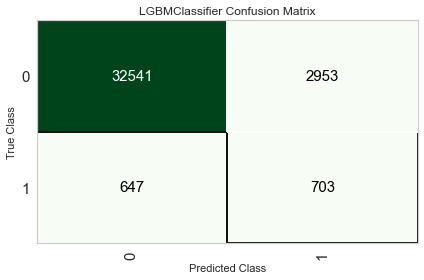

```python
%matplotlib inline
plot_model(tune_light, plot="confusion_matrix")
```

#### ROC Curve

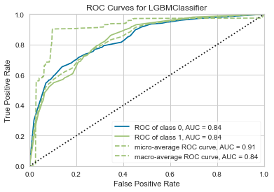

```python
plot_model(tune_light, plot="auc")
```

#### Lift Curve

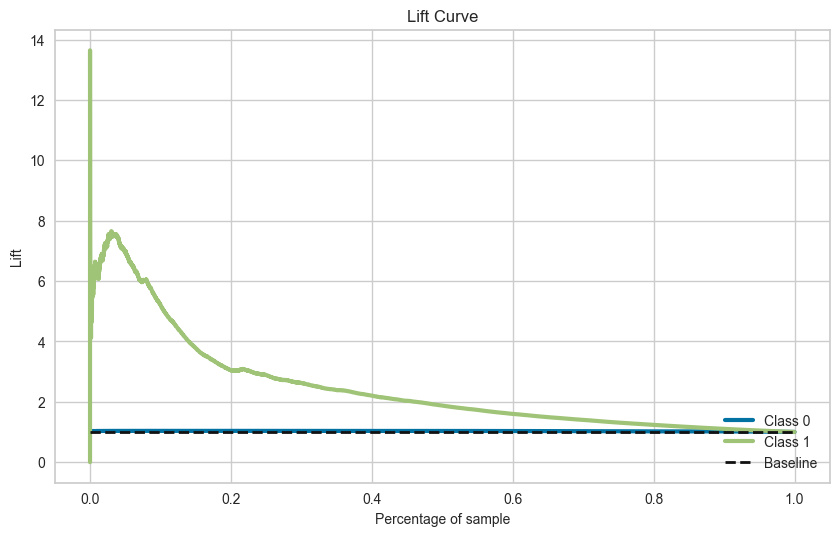

```python
plot_model(tune_light, plot="lift")
```

positive lift and some clear class to target but worried abou the vertical line in the lift, suggests some stability issues

#### Gains

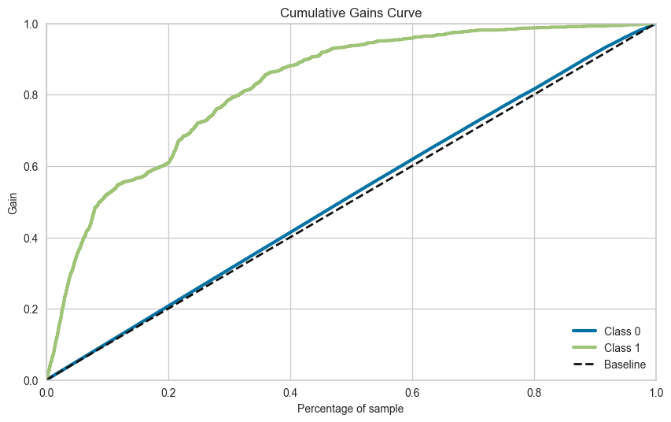

```python
plot_model(tune_light, plot="gain")
```

While we beat the baseline the lines are looking shaky here, consider model stability

#### Feature Importance

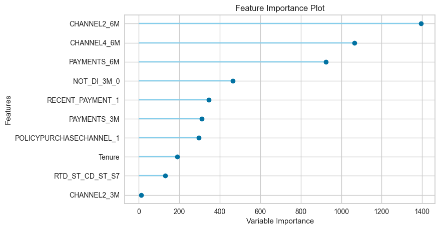

```python
plot_model(tune_light, plot="feature")
```

We can see Channel 2, 4 and payments made in the last 6 months account for a lot, something to consider, what happened to AGE? I thought for sure it would be on of the most influential features along with Tenure

#### PR Curve

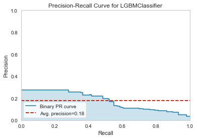

```python
plot_model(tune_light, plot="pr")
```

#### Calibration

Want to check the calibration to make sure its a stable or reliable model, adjust the tuning for that

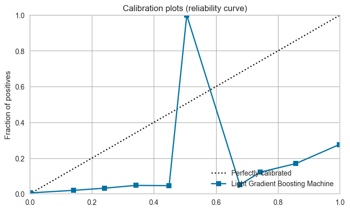

```python
plot_model(tune_light, plot='calibration')
```

```python
cal = calibrate_model(tune_light, method = 'isotonic')
```

| Fold | Accuracy | AUC | Recall | Prec. | F1 | Kappa | MCC |
| --- | --- | --- | --- | --- | --- | --- | --- |
| 0 | 0.8836 | 0.8541 | 0.5841 | 0.1746 | 0.2688 | 0.2251 | 0.2744 |
| 1 | 0.8827 | 0.8669 | 0.6635 | 0.1881 | 0.2931 | 0.2503 | 0.3106 |
| 2 | 0.8736 | 0.8497 | 0.6190 | 0.1678 | 0.2640 | 0.2190 | 0.2760 |
| 3 | 0.8484 | 0.8501 | 0.5873 | 0.1362 | 0.2212 | 0.1719 | 0.2296 |
| 4 | 0.8789 | 0.8302 | 0.5714 | 0.1657 | 0.2570 | 0.2122 | 0.2613 |
| 5 | 0.8618 | 0.8258 | 0.5746 | 0.1466 | 0.2335 | 0.1860 | 0.2396 |
| 6 | 0.8953 | 0.8426 | 0.5302 | 0.1817 | 0.2707 | 0.2286 | 0.2672 |
| 7 | 0.8499 | 0.8459 | 0.6254 | 0.1439 | 0.2340 | 0.1854 | 0.2485 |
| 8 | 0.8709 | 0.8308 | 0.5397 | 0.1498 | 0.2345 | 0.1879 | 0.2349 |
| 9 | 0.8654 | 0.8490 | 0.5968 | 0.1544 | 0.2453 | 0.1986 | 0.2545 |
| Mean | 0.8711 | 0.8445 | 0.5892 | 0.1609 | 0.2522 | 0.2065 | 0.2597 |
| Std | 0.0142 | 0.0119 | 0.0378 | 0.0164 | 0.0211 | 0.0233 | 0.0228 |

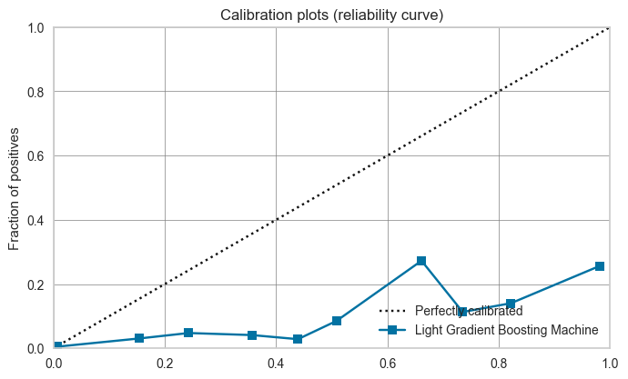

```python
plot_model(cal, plot='calibration')
```

#### Test set evaluation

```python
predict_model(cal)
```

|  | Model | Accuracy | AUC | Recall | Prec. | F1 | Kappa | MCC |
| --- | --- | --- | --- | --- | --- | --- | --- | --- |
| 0 | Light Gradient Boosting Machine | 0.8730 | 0.8419 | 0.6074 | 0.1650 | 0.2595 | 0.2142 | 0.2698 |

|  | Tenure | Age | CHANNEL2_6M | CHANNEL3_6M | CHANNEL4_6M | CHANNEL5_6M | METHOD1_6M | PAYMENTS_6M | CHANNEL2_3M | CHANNEL3_3M | ... | MART_STATUS_MS_S3 | MART_STATUS_MS_S4 | GENDER_M | RECENT_PAYMENT_1 | NOT_DI_3M_0 | NOT_DI_6M_1 | POLICYPURCHASECHANNEL_1 | Call_Flag | Label | Score |
| --- | --- | --- | --- | --- | --- | --- | --- | --- | --- | --- | --- | --- | --- | --- | --- | --- | --- | --- | --- | --- | --- |
| 0 | 0.509984 | -0.287442 | -0.596762 | -0.504408 | -0.502051 | -0.389283 | 1.487011 | 0.561716 | -0.530818 | -0.458380 | ... | 0.0 | 0.0 | 1.0 | 0.0 | 1.0 | 0.0 | 0.0 | 0 | 0 | 0.9289 |
| 1 | -1.565434 | -0.304747 | -0.596762 | -0.504408 | -0.502051 | -0.389283 | -0.827478 | -1.389901 | -0.530818 | -0.458380 | ... | 0.0 | 0.0 | 1.0 | 0.0 | 1.0 | 0.0 | 0.0 | 0 | 0 | 0.9182 |
| 2 | -0.000864 | -1.338562 | 1.815398 | -0.504408 | 1.923020 | -0.389283 | 1.212944 | 0.068023 | 1.917832 | -0.458380 | ... | 0.0 | 0.0 | 1.0 | 0.0 | 1.0 | 0.0 | 0.0 | 0 | 0 | 0.6750 |
| 3 | 0.451683 | 1.050999 | -0.596762 | 2.066555 | -0.502051 | -0.389283 | -0.827478 | -0.421276 | -0.530818 | 2.079866 | ... | 0.0 | 0.0 | 1.0 | 0.0 | 1.0 | 0.0 | 0.0 | 0 | 0 | 0.9182 |
| 4 | 0.230261 | 0.186078 | -0.596762 | 2.095010 | -0.502051 | -0.389283 | -0.827478 | 0.561716 | -0.530818 | 2.218209 | ... | 0.0 | 1.0 | 1.0 | 0.0 | 1.0 | 0.0 | 0.0 | 0 | 0 | 0.9289 |
| ... | ... | ... | ... | ... | ... | ... | ... | ... | ... | ... | ... | ... | ... | ... | ... | ... | ... | ... | ... | ... | ... |
| 36839 | 0.522388 | -1.138608 | -0.596762 | -0.504408 | -0.502051 | -0.389283 | 0.083531 | -1.870776 | -0.530818 | -0.458380 | ... | 0.0 | 0.0 | 1.0 | 0.0 | 1.0 | 0.0 | 0.0 | 0 | 0 | 0.5246 |
| 36840 | -1.535651 | 1.663013 | -0.596762 | -0.504408 | -0.502051 | -0.389283 | -0.827478 | 0.561716 | -0.530818 | -0.458380 | ... | 0.0 | 0.0 | 1.0 | 0.0 | 1.0 | 0.0 | 0.0 | 0 | 0 | 0.9289 |
| 36841 | 0.297203 | 0.738482 | 1.580040 | -0.504408 | 2.058802 | -0.389283 | 1.212944 | -0.421276 | 1.717991 | -0.458380 | ... | 0.0 | 0.0 | 0.0 | 0.0 | 1.0 | 0.0 | 0.0 | 0 | 1 | 0.7713 |
| 36842 | -1.698492 | -0.639168 | -0.596762 | -0.504408 | 1.923020 | -0.389283 | 0.659079 | -0.906923 | -0.530818 | -0.458380 | ... | 0.0 | 0.0 | 1.0 | 1.0 | 0.0 | 1.0 | 1.0 | 0 | 0 | 0.7768 |
| 36843 | -0.848035 | -1.171067 | -0.596762 | -0.504408 | 2.091370 | -0.389283 | 0.659079 | 1.058751 | -0.530818 | -0.458380 | ... | 0.0 | 0.0 | 1.0 | 1.0 | 0.0 | 1.0 | 0.0 | 1 | 0 | 0.7734 |

36844 rows × 84 columns

**GREAT** test set performance can use this model with a large amount of gains initiallly, something to consider we don't want to target people that have already signed up for the automatic program, while they were useful in the training since they helped to define classes I wouldn't use them in the final

#### Finalize Model

```python
final_rf = finalize_model(bagged_model)
```

[output not shown]

```python
save_model(cal,'..//mdl//light gbm final -- 2022')
```

```
Transformation Pipeline and Model Successfully Saved
```

[output not shown]

#### Holdout Evaluation

```python
predict_model(cal, data = holdout)
```

|  | Model | Accuracy | AUC | Recall | Prec. | F1 | Kappa | MCC |
| --- | --- | --- | --- | --- | --- | --- | --- | --- |
| 0 | Light Gradient Boosting Machine | 0.8704 | 0.8343 | 0.5689 | 0.1473 | 0.2340 | 0.1892 | 0.2419 |

|  | RTD_ST_CD | CustomerSegment | Tenure | Age | MART_STATUS | GENDER | CHANNEL1_6M | CHANNEL2_6M | CHANNEL3_6M | CHANNEL4_6M | ... | PAYMENTS_3M | NOT_DI_3M | NOT_DI_6M | EVENT1_30_FLAG | EVENT2_90_SUM | LOGINS | POLICYPURCHASECHANNEL | Call_Flag | Label | Score |
| --- | --- | --- | --- | --- | --- | --- | --- | --- | --- | --- | --- | --- | --- | --- | --- | --- | --- | --- | --- | --- | --- |
| 12714 | ST_S42 | 1 | 16.268309 | 65.393566 | MS_S0 | F | 0 | 0 | 6 | 0 | ... | 3 | 0 | 0 | 0 | 0 | 0 | 0 | 0 | 0 | 0.9289 |
| 38158 | ST_S14 | 1 | 9.834360 | 45.957563 | MS_S2 | M | 0 | 0 | 0 | 0 | ... | 3 | 0 | 0 | 0 | 0 | 1 | 0 | 0 | 0 | 0.9289 |
| 79677 | ST_S6 | 3 | 4.974675 | 26.294319 | MS_S1 | F | 0 | 0 | 0 | 0 | ... | 4 | 0 | 0 | 0 | 0 | 2 | 0 | 0 | 0 | 0.9289 |
| 117390 | ST_S38 | NONE | 1.015743 | 42.447639 | MS_S2 | M | 0 | 0 | 0 | 0 | ... | 1 | 0 | 0 | 0 | 0 | 2 | 1 | 0 | 0 | 0.8183 |
| 87003 | ST_S6 | 3 | 4.008214 | 22.789870 | MS_S1 | M | 0 | 0 | 0 | 0 | ... | 0 | 0 | 0 | 0 | 0 | 1 | 1 | 0 | 0 | 0.9182 |
| ... | ... | ... | ... | ... | ... | ... | ... | ... | ... | ... | ... | ... | ... | ... | ... | ... | ... | ... | ... | ... | ... |
| 114359 | ST_S7 | 1 | 1.188227 | 29.204654 | MS_S1 | M | 2 | 0 | 0 | 0 | ... | 3 | 0 | 1 | 0 | 0 | 9 | 0 | 0 | 0 | 0.9289 |
| 1076 | ST_S41 | 1 | 16.991102 | 50.006845 | MS_S1 | M | 0 | 0 | 3 | 3 | ... | 3 | 0 | 0 | 0 | 0 | 0 | 0 | 0 | 0 | 0.7734 |
| 486 | ST_S9 | 1 | 16.188912 | 46.417522 | MS_S2 | M | 0 | 0 | 6 | 0 | ... | 3 | 0 | 0 | 0 | 0 | 0 | 0 | 0 | 0 | 0.9289 |
| 98003 | ST_S3 | 1 | 2.798084 | 31.049966 | MS_S2 | F | 2 | 4 | 0 | 0 | ... | 3 | 0 | 1 | 0 | 0 | 0 | 0 | 0 | 0 | 0.5968 |
| 50770 | ST_S9 | 1 | 8.079398 | 50.598220 | MS_S2 | M | 0 | 1 | 0 | 0 | ... | 0 | 0 | 0 | 0 | 0 | 0 | 0 | 0 | 1 | 0.7644 |

6464 rows × 30 columns

Good holdout perf the model seems stable! with good recall, remember to target the appropriate customers and also to further build upon this work with the team to build out cost matrixes to optimize along actual cost to the buisness

#### Thank you!

Thanks for the opportunity to apply at Geico, I hope this notebook was self documenting but happy to walk through my code and thoughts and look forward to our conversation.

If this didn't meet your standards, I thouroughly enjoyed the application process and wish you the best of luck!

```python
!pip39 freeze > requirements.txt
```

```
zsh:1: command not found: pip39
```